# Lab 9 - Hierarchical Clustering

## Name and ID: Roy Paz

```python
! mkdir ~/.kaggle
! cp kaggle.json ~/.kaggle/
! chmod 600 ~/.kaggle/kaggle.json
! kaggle datasets download jamessteve/categorized-news-articles
! unzip /content/categorized-news-articles.zip
```

```
mkdir: cannot create directory ‘/root/.kaggle’: File exists
categorized-news-articles.zip: Skipping, found more recently modified local copy (use --force to force download)
Archive:  /content/categorized-news-articles.zip
replace news_articles.csv? [y]es, [n]o, [A]ll, [N]one, [r]ename: Y
  inflating: news_articles.csv
```

```python
import pandas as pd

data = pd.read_csv('/content/news_articles.csv')
data = data.drop('url', axis=1)
data.head(10)
```

|  | category | body |
| --- | --- | --- |
| 0 | business | easyjet and cruise firm carnival are to lose t... |
| 1 | business | british airways is in a bitter standoff with u... |
| 2 | business | us trade representative robert lighthizer the... |
| 3 | business | google adelie foods was hit by a drop in the ... |
| 4 | business | matthew horwood some 300,000 more uk workers ... |
| 5 | business | a majority of investors, bankers and brokers w... |
| 6 | business | house prices fell 1.7% in may from the previou... |
| 7 | business | david azia/oxfam oxfam has asked people to ca... |
| 8 | business | zoom zoom has become the app many are using t... |
| 9 | business | the drag on the us economy from the virus pand... |

Articles were preprocess using Doc2Vec embedding model, to be represented with a high-dimentionality vector.

X Holds the vectorized articles data.

Interested in Doc2Vec? read more [here](https://radimrehurek.com/gensim/models/doc2vec.html)

```python
import nltk
from nltk.corpus import stopwords
import string
from gensim.models.doc2vec import Doc2Vec, TaggedDocument
from nltk.tokenize import word_tokenize


nltk.download('stopwords')
nltk.download('punkt')
stop = set(stopwords.words('english') + list(string.punctuation))
# tokenize each article while removing stopwords and checking the length
tokenized_docs = [[word for word in word_tokenize(d.lower()) if word not in stop and len(word)>1] for d in data['body']]

tagged_data = [TaggedDocument(d, data['category'][i]) for i, d in enumerate(tokenized_docs)]

model = Doc2Vec(tagged_data, vector_size=100, window=5, min_count=1, workers=4)
model.random.seed(2023)
X = [model.infer_vector(x) for x in tokenized_docs]
```

## Task 1:

Explore the label distribution of the documents.

Perform dimensionality reduction on the vectorized articles using **Isomap** to plot the data points according to the label.

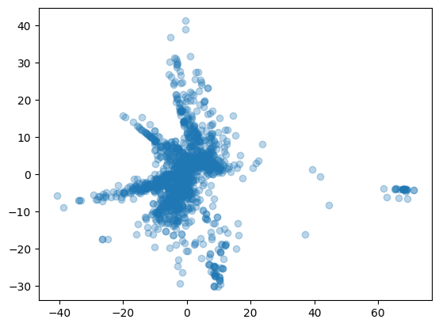

```python
# implement here
from sklearn.manifold import Isomap
import matplotlib.pyplot as plt

embedding = Isomap(n_components=2)
X_transformed = embedding.fit_transform(X)
plt.scatter(X_transformed[:,:1],X_transformed[:,1:], alpha= 0.3)
plt.show()
```

## Task 2:

Create basic AgglomerativeClustering model with the parameters: n_clusters=10, affinity='cosine', linkage='complete', compute_distances=True

Plot the first 4 levels of dendrogram using the function 'plot_dendrogram' bellow with the parameters: truncate_mode="level", p=3. Find cutoff line for 10 clusters and plot it (using plt.axhline). This line represents the distance threshold.

plot the clustering of the model and the true clustering next to each other for visualize comparison

```python
from scipy.cluster.hierarchy import dendrogram
import numpy as np

def plot_dendrogram(model, **kwargs):
    counts = np.zeros(model.children_.shape[0])
    n_samples = len(model.labels_)
    for i, merge in enumerate(model.children_):
        current_count = 0
        for child_idx in merge:
            if child_idx < n_samples:
                current_count += 1  # leaf node
            else:
                current_count += counts[child_idx - n_samples]
        counts[i] = current_count

    linkage_matrix = np.column_stack([model.children_, model.distances_, counts]).astype(float)

    # Plot the corresponding dendrogram
    dendrogram(linkage_matrix, **kwargs)
```

```python
from sklearn.cluster import AgglomerativeClustering
clustering = AgglomerativeClustering(n_clusters=10, affinity='cosine',
                                     linkage='complete', compute_distances=True).fit(X)
```

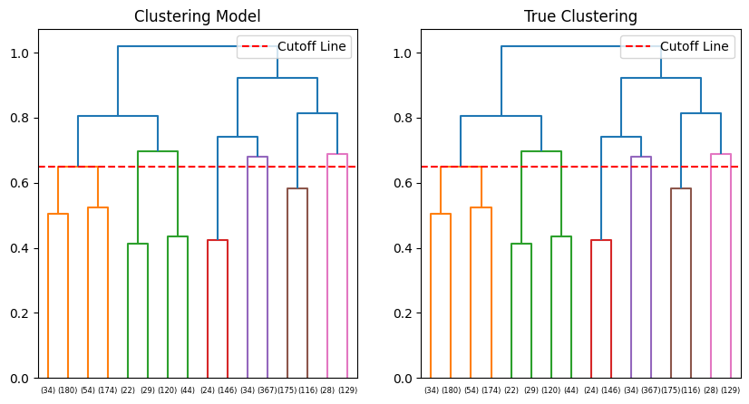

```python
from scipy.cluster.hierarchy import dendrogram, linkage


plt.figure(figsize=(10, 5))
plt.subplot(1, 2, 1)
plot_dendrogram(clustering, truncate_mode="level", p=3)
cutoff_line = clustering.distances_[-10 + 1]
plt.axhline(y=cutoff_line, color='r', linestyle='--', label='Cutoff Line')
plt.legend()
plt.title('Clustering Model')
plt.tick_params(axis='x', labelsize=6)


# Perform hierarchical clustering
plt.subplot(1, 2, 2)
linkage_matrix = linkage(X, method='complete', metric='cosine')
dendrogram(linkage_matrix, truncate_mode='level', p=3)
cutoff_line = clustering.distances_[-10 + 1]
plt.axhline(y=cutoff_line, color='r', linestyle='--', label='Cutoff Line')
plt.legend()
plt.title('True Clustering')
plt.tick_params(axis='x', labelsize=6)

plt.show()
```

## Task 3:

The Silhouette Coefficient is defined for each sample and is composed of two scores:

- a: The mean distance between a sample and all other points in the same cluster.
- b: The mean distance between a sample and all other points in the next nearest cluster.

The Silhouette Coefficient for a set of samples is given as the mean of the Silhouette Coefficient for each sample. The score is bounded between -1 for incorrect clustering and +1 for highly dense clustering. Scores around zero indicate overlapping clusters. The score is higher when clusters are dense and well separated, which relates to a standard concept of a cluster.

Select **one** of the hyperparameters of the AgglomerativeClustering model, and try different values while saving the silhouette_score of each configuration. print the scores and the parameters that achieved it.

```python
# implement here
from sklearn.metrics import silhouette_score
scores = []
vals = [6,8,10,12]
for v in vals:
  clustering = AgglomerativeClustering(n_clusters=v, affinity='cosine',
                                      linkage= 'complete', compute_distances=True).fit(X)
  scores.append(silhouette_score(X,clustering.labels_))
print(f"scores: {scores}, clusters: {vals}")
```

```
scores: [0.06349776, 0.07476723, 0.049335334, 0.055764038], clusters: [6, 8, 10, 12]
```

## Task 4:

Repeat Task 2 on a new AgglomerativeClustering model with the configuration that achieved the best silhouette_score

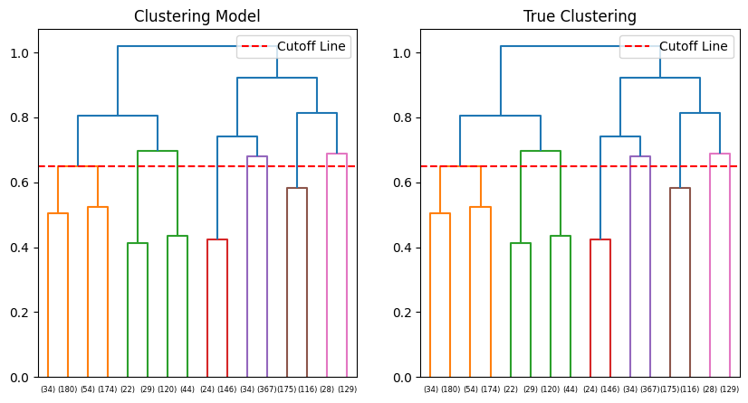

```python
from sklearn.cluster import AgglomerativeClustering
clustering = AgglomerativeClustering(n_clusters=8, affinity='cosine',
                                     linkage='complete', compute_distances=True).fit(X)

plt.figure(figsize=(10, 5))
plt.subplot(1, 2, 1)
plot_dendrogram(clustering, truncate_mode="level", p=3)
cutoff_line = clustering.distances_[-10 + 1]
plt.axhline(y=cutoff_line, color='r', linestyle='--', label='Cutoff Line')
plt.legend()
plt.title('Clustering Model')
plt.tick_params(axis='x', labelsize=6)


# Perform hierarchical clustering
plt.subplot(1, 2, 2)
linkage_matrix = linkage(X, method='complete', metric='cosine')
dendrogram(linkage_matrix, truncate_mode='level', p=3)
cutoff_line = clustering.distances_[-10 + 1]
plt.axhline(y=cutoff_line, color='r', linestyle='--', label='Cutoff Line')
plt.legend()
plt.title('True Clustering')
plt.tick_params(axis='x', labelsize=6)

plt.show()
```

## Task 5:

Convert the notebook into html:

1. Download the notebook by clicking the File tab
2. Upload it to this environment
3. Run the command:

```python
%%shell
jupyter nbconvert --to html Lab9.ipynb
```

[output not shown]

[output cut: 133 more lines]

[output not shown]

[output not shown]